# Лабораторна робота 2. Побудова лінійного бінарного класифікатора на основі оптимізації функціонала якості

Мета: реалізузвати бінарний класифікатор на основі оптимізації функціонала якості засобами мови Python

## Що ви будете вміти?

- Використовувати деякі можливості бібліотеки `NumPy`
- Реалізувати простий лінійний класифікатор на основі оптимізації функціонала якості засобами мови Python

## Завдання для самостійної роботи

1. Імпортувати дані для навчальної вибірки згідно з індивідуальним варіантом (імпорт організувати з файлу).
2. Побудувати бінарний МНК-класифікатор згідно з розглянутим вище прикладом і вивести результати бінарної класифікації на графіку.
3. Проаналізувати отримані результати і порівняти їх з результатами, отриманими у лаб роб. 1.
4. Дати відповіді на контрольні запитання.
5. Відправити результати роботи у файлі lab_2_StudentLastName.ipynb до віддаленого репозиторію на GіtHub.

## Хід роботи

Спочатку імпортуємо навчальну вібирку, яку будемо використовувати для побудови МНК-оцінки для вектора ваг $w$

```python
import pandas as pd
from data.training_sample import x_train, y_train

df = pd.DataFrame(x_train, columns=["x1", "x2"])
df["class"] = y_train

df
```

|  | x1 | x2 | class |
| --- | --- | --- | --- |
| 0 | 49 | 50 | -1 |
| 1 | 5 | 29 | -1 |
| 2 | 37 | 41 | -1 |
| 3 | 38 | 38 | -1 |
| 4 | 13 | 5 | 1 |
| 5 | 41 | 27 | 1 |
| 6 | 7 | 32 | -1 |
| 7 | 40 | 18 | -1 |
| 8 | 31 | 18 | 1 |
| 9 | 41 | 31 | -1 |

Теперь побудуємо бінарний МНК-класифікатор та виведо результати на графіку

```
[ 0.01429799 -0.05626971  0.79439528]
```

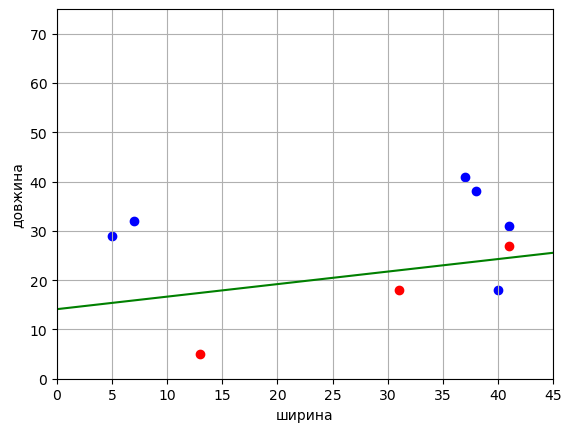

```python
import numpy as np
import matplotlib.pyplot as plt

x_train = [x + [1] for x in x_train]  # Додаємо зміщення для кожного прикладу
x_train = np.array(x_train)
y_train = np.array(y_train)

pt = np.sum([x * y for x, y in zip(x_train, y_train)], axis=0)  # Обчислення підсумку
xxt = np.sum([np.outer(x, x) for x in x_train], axis=0)  # Обчислення підсумку зовнішнього добутку
w = np.dot(pt, np.linalg.inv(xxt))  # Обчислення вагових коефіцієнтів
print(w)

line_x = list(range(max(x_train[:, 0])))    # формування координат для лінії розділення
line_y = [-x*w[0]/w[1] - w[2]/w[1] for x in line_x]

x_0 = x_train[y_train == 1]                 # формування точок для класу 1
x_1 = x_train[y_train == -1]                # і класу -1

plt.scatter(x_0[:, 0], x_0[:, 1], color='red')  # відображення точок класу 1 червоним кольором
plt.scatter(x_1[:, 0], x_1[:, 1], color='blue')  # відображення точок класу -1 синім кольором
plt.plot(line_x, line_y, color='green')  # відображення лінії розділення зеленим кольором

plt.xlim([0, 45])
plt.ylim([0, 75])
plt.ylabel("довжина")
plt.xlabel("ширина")
plt.grid(True)
plt.show()
```

# Контрольні питання

1. Що таке відступ (margin) і яка його роль в побудові моделі класифікації?

   Відступ - це міра правильності прогнозу для кожного об'єкта. Якщо відступ $< 0$, то це означає що передбачення помилкове і воно потребує коригування, якщо $> 0$ - передбачення правильне і ніяких змін модель не потребує.
2. Яка роль функції втрат і чому не можна знайти коефіцієнти лінійного класифікатора шляхом безпосереднього розв’язаня задачі оптимізації через знаходження похідної?

   Для знаходження МНК-оцінки классифікатора треба взяти похідну функції втрат і прирівняти її до нуля. Через неї знаходится такий вектор ваг $w$, який досягає мінімума помилок на графіку $a(x,w)$. Але така функція не є диференційованою, тому що має різкий розрив. Щоб знайти похідну підбирається формула суми найменших квадратів (функціонал якості), яка може бути використана для підрахунку сумарного штрафу по всій вибірці і може бути диференційована.
3. Чим приницпово розрізняється алгоритм, розглянутий у цій роботі від алгоритму, розглянутого у лаб. роб 1?

   МНК розв’язує задачу класифікації як задачу оптимізації, тобто шукає мінімуми оба максимуми фукнції. Алгоритм Розенблатта - це евристичне правило без оптимізації: він просто перебирає об’єкти і коригує вагу лише тоді, коли трапляється помилка.
4. Вивести математичний вираз для оцінки вектора

   $\omega^T = \sum_{i=1}^{l} x_i^T y_i \cdot \left(\sum_{i=1}^{l} x_i x_i^T\right)^{-1}$, де
   - $\sum_{i=1}^{l} x_i^T y_i$ - сумма вхідних векторів і міток класів
   - $\sum_{i=1}^{l} x_i x_i^T$ - матриця кореляцій між ознаками